# AIRSIS QC Options

Jonathan Callahan

2022-10-11

## Quality Control

This mini-report examines PM2.5 data values from temporary monitors whose data is obtained from AIRSIS (aka Oceaneering).

We will explore various QC options that can be used to improve trust in the data without invalidating valid outliers that may identify periods of intense smoke from wildfires.

### Engineering-level QC

All data used in this report have already had instrument specific QC applied. During data processing of *engineering-level* data, PM2.5 values were invalidated if other measurements such as Internal Relative Humidity or Air Flow were out of spec, indicating that the instrument was not working properly. This level of QC only works on one record at a time.

The term “Raw” below refers to post-engineering-level-QC.

### “Raw” Data Problems

We will use AIRSIS data from 2020 to highlight some of the issues that must be dealt with.

A simple plot of data from all 165 temporary monitors in 2020 reveals many occurences of 1000, 2000, *etc.* Many of these are obviously incorrect and need to be removed.

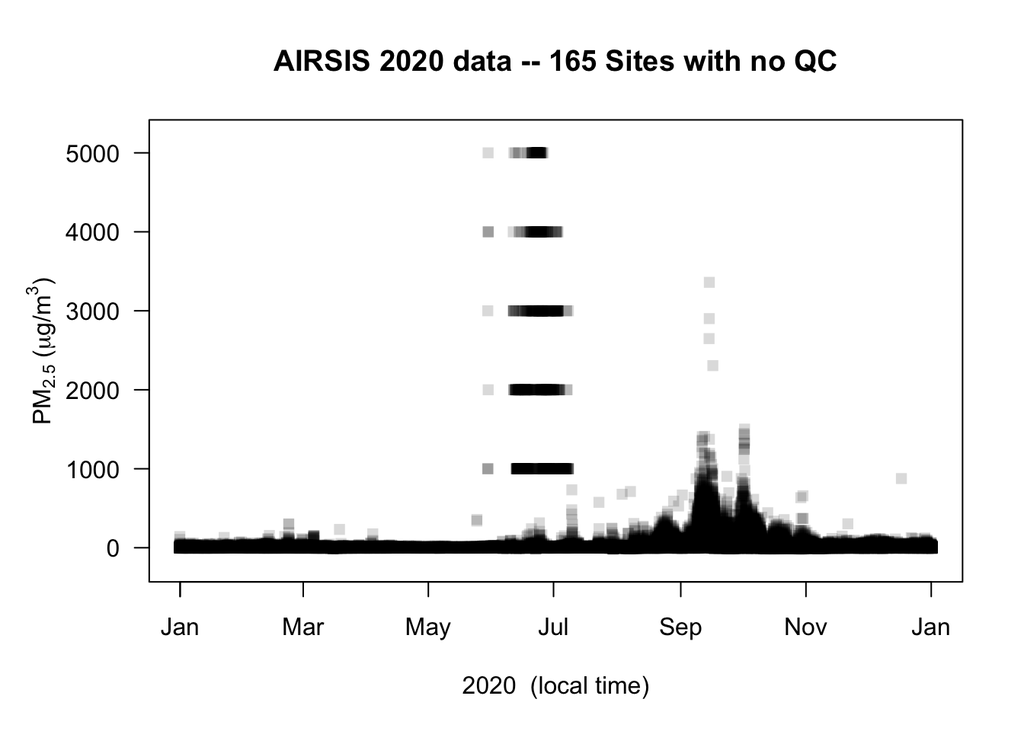

```r
library(AirMonitor)

airsis_no_QC <-
  airsis_loadAnnual(
    2020,
    QC_negativeValues = "ignore",
    QC_removeSuspectData = FALSE
  )

monitor_timeseriesPlot(airsis_no_QC, main = "AIRSIS 2020 data -- 165 Sites with no QC")
```

### QC: Remove “Sticky” Values

We can create an algorithm that invalidates (*i.e.* replaces with `NA`) the obviously bad values:

```
1. identify all "suspect values" (NA, 0, 1K, 2K, 3K, ...)
2. identify any consecutive sequence of suspect values of length 2 or more
3. invalidate every value that is part of such a sequence
```

Applying this “sticky values” QC, we can remove all of the visually obvious bad values:

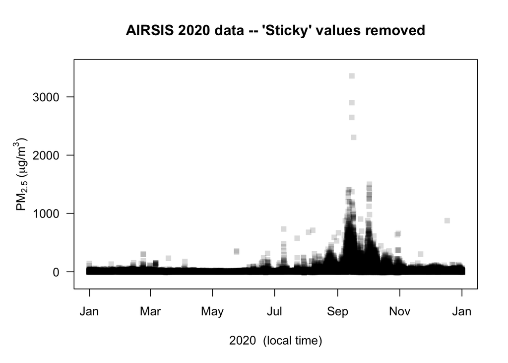

```r
airsis_no_sticky <-
  airsis_loadAnnual(
    2020,
    QC_negativeValues = "ignore",
    QC_removeSuspectData = TRUE
  )

monitor_timeseriesPlot(airsis_no_sticky, main = "AIRSIS 2020 data -- 'Sticky' values removed")
```

But if we look closely near zero we see many negative values:

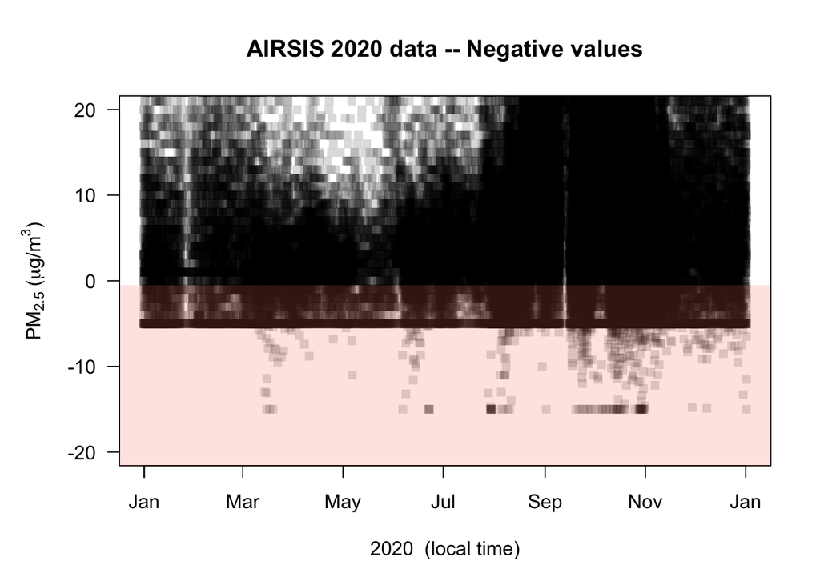

```r
monitor_timeseriesPlot(airsis_no_sticky, main = "AIRSIS 2020 data -- Negative values", ylim = c(-20, 20))
usr <- par()$usr
rect(
  usr[1], usr[3], usr[2], -0.5,
  col = adjustcolor("salmon", 0.2),
  border = NA
)
```

### QC: Remove negative values

Negative values of aerosol density are not possible. They are “aphysical”.

There are many reasons why an instrument might report negative values, several of them related to electronics: bias voltages within sensors; amplifiers may need calibration; *etc.*

Without a deep dive into the engineering data for each instrument, the best way to resolve these “aphysical” values is to convert them to zero. Most of these values are small numbers anyway, so conversion to zero can be seen as “rounding up” to the nearest physically sensible value.

Here is a final version of the AIRSIS 2020 data with

- removal of consecutive suspect values
- converstion of negative values to zero

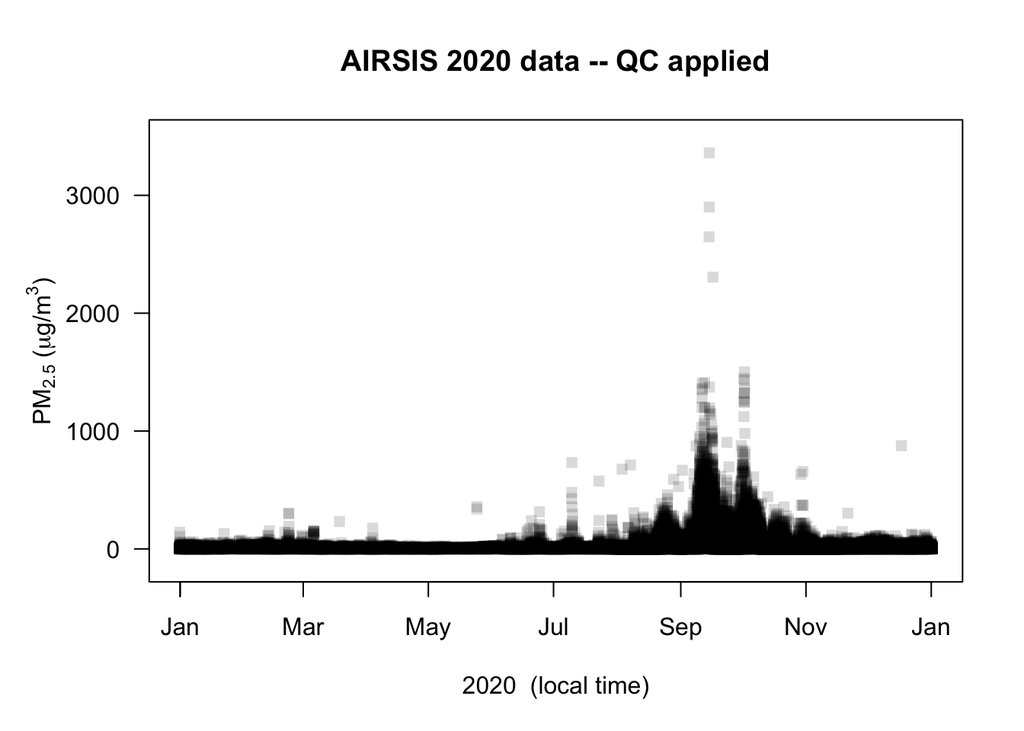

```r
airsis <-
  airsis_loadAnnual(
    2020,
    QC_negativeValues = "zero",
    QC_removeSuspectData = TRUE
  )

monitor_timeseriesPlot(airsis, main = "AIRSIS 2020 data -- QC applied")
```

## Extreme Values

We can subset this dataset to include only those monitors that recorded values equal to or greater than 500 ug/m3. This subset contains 24 sites presented on the map below. Most are in valley locations where diurnal breezes can concentrate wildfire smoke generated in the surrounding mountains.

```r
worst_sites <-
  airsis %>%
  monitor_selectWhere(
    function(x) { any(x >= 500, na.rm = TRUE) }
  )

monitor_leaflet(worst_sites)
```

[interactive chart not shown]

Plotting the annual timeseries for these “worst” sites shows that September saw the most smoke with 18 monitors registering values >= 500 ug/m3.

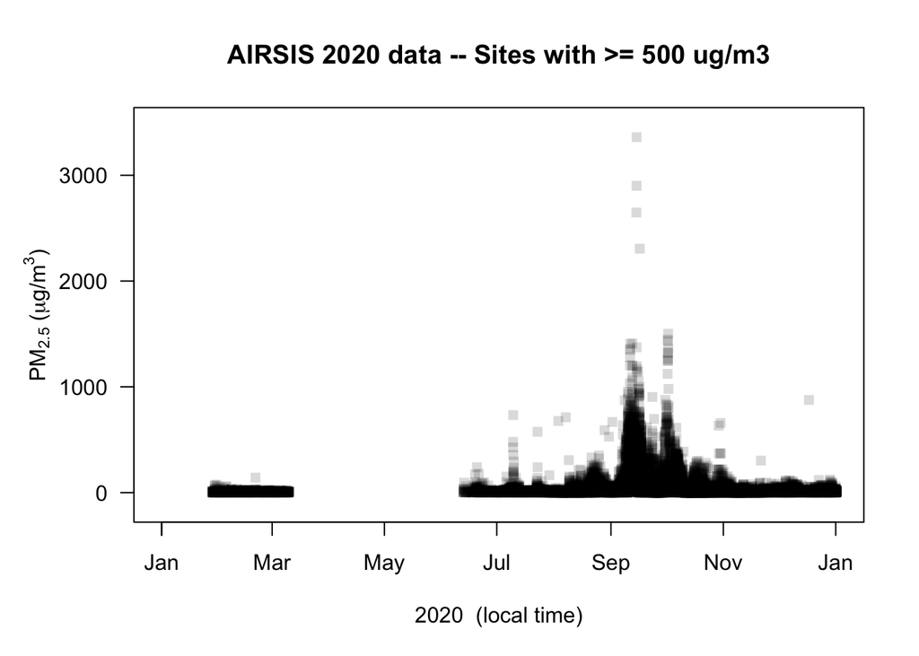

```r
worst_sites %>%
  monitor_timeseriesPlot(main = "AIRSIS 2020 data -- Sites with >= 500 ug/m3")
```

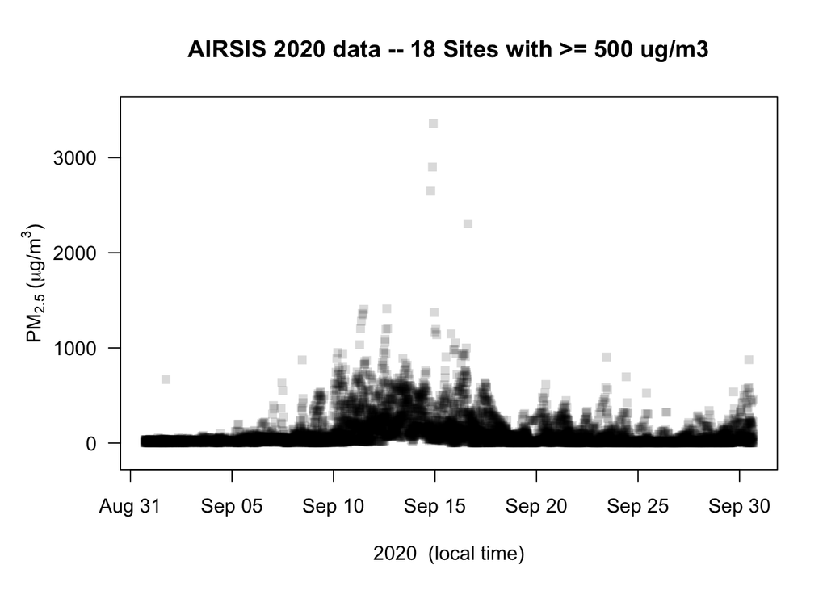

```r
worst_sites_september <-
  airsis %>%
  monitor_filterDate(20200901, 20201001, timezone = "UTC") %>%
  monitor_selectWhere(
    function(x) { any(x >= 500, na.rm = TRUE) }
  )

worst_sites_september %>%
  monitor_timeseriesPlot(main = "AIRSIS 2020 data -- 18 Sites with >= 500 ug/m3")
```

### Timeseries Inspection

The next three plots present each individual timeseries (dots) along with the NowCast (lines) so we can visually inspect them for suspect measurements.

*Note: These plots do not show any of the (very few) values above 1500 ug/m3*

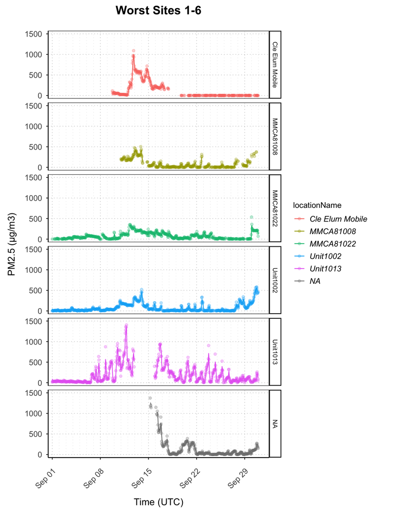

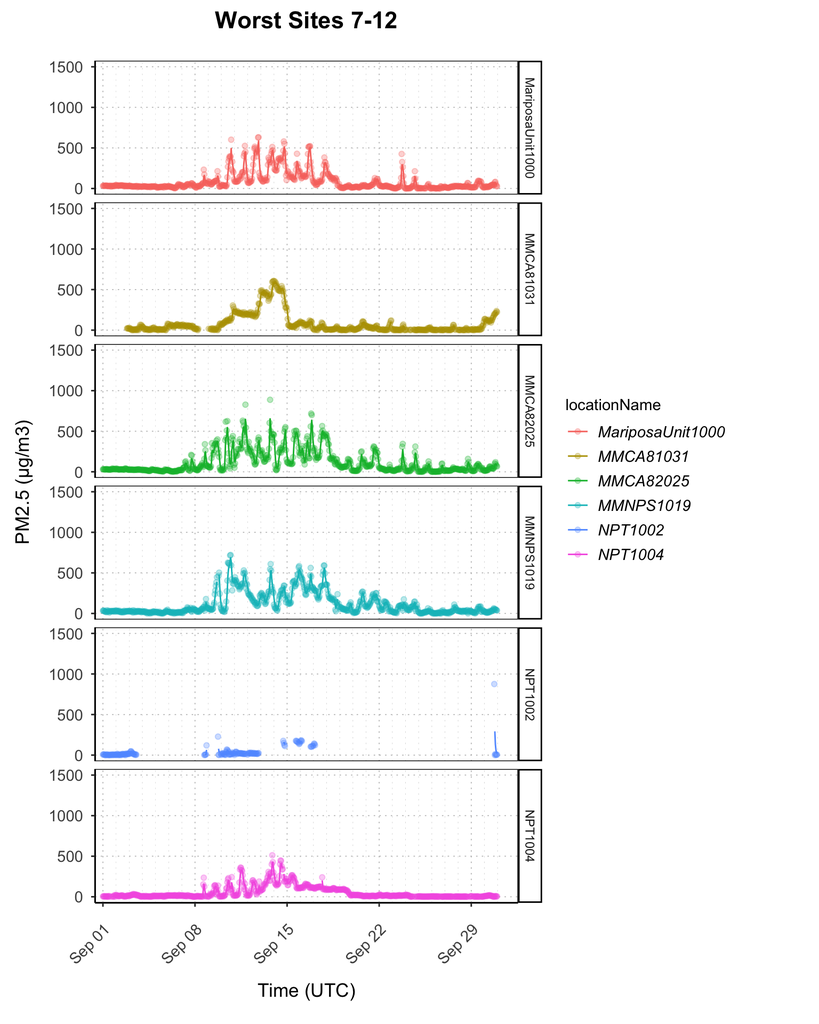

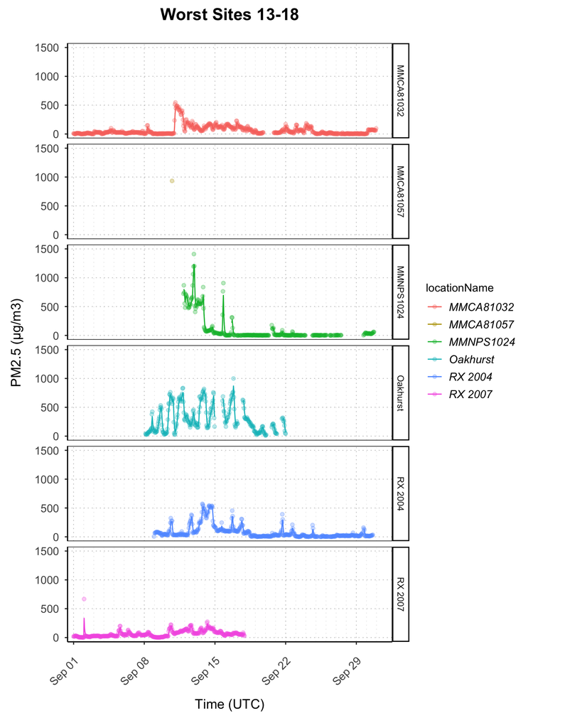

For almost all instruments, measurements above 500 or even above 1000 ug/m3 seem quite reasonable in the context of surrounding points.